# 3.1

**Комментарий ревьюера**  
Привет, Глеб :) Спасибо, что прислал задание 🤝 Меня зовут Ринат Хисамов и я буду проверять твой проект. Предлагаю обращаться друг к другу на ты. Так нам будет гораздо проще и удобней общаться

Мои комментарии обозначены пометкой **Комментарий ревьюера**. Далее в файле сможешь найти их в похожих ячейках (если фон комментария зелёный — всё сделано правильно (✔️), рекомендации таким же цветом. Отдельным цветом — блок ссылок (примеры ниже, 🍕). Оранжевым или светло желтым рекомендации, которые, хоть и не обязательны, но точно сделают ревью лучше. (⚠️); красный комментарий: код, график или вывод стоит переделать (❌)).

Не удаляй все эти комментарии и постарайся учесть их в ходе выполнения данного проекта. Будет замечательно, если добавишь свои комментарии и пояснения✍ Поехали 🚀

**Примеры комментариев**

**🍕 Пример комментария - совета, здесь м.б. просто ссылка**  
Тут всего такого разного и вкусного :), есть способы прокачать проект визуализациями (ценит большинство "боссов")  
[“Библиотека Matplotlib” доступна для скачивания БЕСПЛАТНО!](https://devpractice.ru/matplotlib-book/) На сайте много полезных материалов, мне самому очень помогло в свое время, до сих пор подсматриваю :)

**⚠️ Пример оформления некритичного комментария**  
Рекомендации, которые, хоть и не обязательны, но точно сделают ревью лучше

**❌ Пример оформления комментария к блоку(строке) программного кода (или выводу), который стоит переделать**  
Отправлен не тот проект, напиши в своих комментариях, что случилось? жду — **это пример**

**✔️ Пример оформления комментария, который нравится большинству студентов**  
Круто, молодец, отлично, логично, или — 👌, 👍, или — выводы отвечают на все вопросы к данным и проекту

# Для твоих вопросов или комментариев оставлю такую ячейку, чтобы было удобнее взаимодействовать на проекте

**✍ Комментарий студента**  
... , вот мой вопрос ...

я не понмаю сколько какой % допустим пропусков. На скольео я изначально понял,пропусков не должно быть,но после ревью и почитав документацию, я пришел к выводу что пропуски это не так плохо. не верные данные по типу потолков надо менять на NaN.Правильно понял? Если нет возможности востановить как с площадью, то тоже оставляем NaN. Если есть доп материал по работе с пропусками и аномалими именно сто с нрми делать, прикрепить пожалуйста,чтобы лучше понять логику.

# Исследование объявлений о продаже квартир

В вашем распоряжении данные сервиса Яндекс Недвижимость — архив объявлений о продаже квартир в Санкт-Петербурге и соседних населённых пунктах за несколько лет. Вам нужно научиться определять рыночную стоимость объектов недвижимости. Для этого проведите исследовательский анализ данных и установите параметры, влияющие на цену объектов. Это позволит построить автоматизированную систему: она отследит аномалии и мошенническую деятельность.

По каждой квартире на продажу доступны два вида данных. Первые вписаны пользователем, вторые — получены автоматически на основе картографических данных. Например, расстояние до центра, аэропорта и других объектов — эти данные автоматически получены из геосервисов. Количество парков и водоёмов также заполняется без участия пользователя.

**⚠️ Комментарий ревьюера**  
Название, краткое вступление в работу и главная задача зафиксированы.

Четкий план работ и перечень основных задач позволит коллегам быстрее вникнуть в суть проекта, + будет легче идти к главной цели проекта

### Откройте файл с данными и изучите общую информацию

**⚠️ Комментарий ревьюера**  
Cтоит делить блок загрузки библиотек и код загрузки датасета, в случае необходимости добавления новых библиотек не придется загружать весь датасет заново и перезапускать проект целиком

```python
import pandas as pd
import matplotlib.pyplot as plt
import seaborn as sns
import numpy as np
```

```python
data = pd.read_csv('C:\\Users\\glebe\\Downloads\\real_estate_data.csv', sep='\t')
data.head()
```

|  | total_images | last_price | total_area | first_day_exposition | rooms | ceiling_height | floors_total | living_area | floor | is_apartment | ... | kitchen_area | balcony | locality_name | airports_nearest | cityCenters_nearest | parks_around3000 | parks_nearest | ponds_around3000 | ponds_nearest | days_exposition |
| --- | --- | --- | --- | --- | --- | --- | --- | --- | --- | --- | --- | --- | --- | --- | --- | --- | --- | --- | --- | --- | --- |
| 0 | 20 | 13000000.0 | 108.0 | 2019-03-07T00:00:00 | 3 | 2.70 | 16.0 | 51.0 | 8 | NaN | ... | 25.0 | NaN | Санкт-Петербург | 18863.0 | 16028.0 | 1.0 | 482.0 | 2.0 | 755.0 | NaN |
| 1 | 7 | 3350000.0 | 40.4 | 2018-12-04T00:00:00 | 1 | NaN | 11.0 | 18.6 | 1 | NaN | ... | 11.0 | 2.0 | посёлок Шушары | 12817.0 | 18603.0 | 0.0 | NaN | 0.0 | NaN | 81.0 |
| 2 | 10 | 5196000.0 | 56.0 | 2015-08-20T00:00:00 | 2 | NaN | 5.0 | 34.3 | 4 | NaN | ... | 8.3 | 0.0 | Санкт-Петербург | 21741.0 | 13933.0 | 1.0 | 90.0 | 2.0 | 574.0 | 558.0 |
| 3 | 0 | 64900000.0 | 159.0 | 2015-07-24T00:00:00 | 3 | NaN | 14.0 | NaN | 9 | NaN | ... | NaN | 0.0 | Санкт-Петербург | 28098.0 | 6800.0 | 2.0 | 84.0 | 3.0 | 234.0 | 424.0 |
| 4 | 2 | 10000000.0 | 100.0 | 2018-06-19T00:00:00 | 2 | 3.03 | 14.0 | 32.0 | 13 | NaN | ... | 41.0 | NaN | Санкт-Петербург | 31856.0 | 8098.0 | 2.0 | 112.0 | 1.0 | 48.0 | 121.0 |

5 rows × 22 columns

```python
data.info()
```

```
<class 'pandas.core.frame.DataFrame'>
RangeIndex: 23699 entries, 0 to 23698
Data columns (total 22 columns):
 #   Column                Non-Null Count  Dtype
---  ------                --------------  -----
 0   total_images          23699 non-null  int64
 1   last_price            23699 non-null  float64
 2   total_area            23699 non-null  float64
 3   first_day_exposition  23699 non-null  object
 4   rooms                 23699 non-null  int64
 5   ceiling_height        14504 non-null  float64
 6   floors_total          23613 non-null  float64
 7   living_area           21796 non-null  float64
 8   floor                 23699 non-null  int64
 9   is_apartment          2775 non-null   object
 10  studio                23699 non-null  bool
 11  open_plan             23699 non-null  bool
 12  kitchen_area          21421 non-null  float64
 13  balcony               12180 non-null  float64
 14  locality_name         23650 non-null  object
 15  airports_nearest      18157 non-null  float64
 16  cityCenters_nearest   18180 non-null  float64
 17  parks_around3000      18181 non-null  float64
 18  parks_nearest         8079 non-null   float64
 19  ponds_around3000      18181 non-null  float64
 20  ponds_nearest         9110 non-null   float64
 21  days_exposition       20518 non-null  float64
dtypes: bool(2), float64(14), int64(3), object(3)
memory usage: 3.7+ MB
```

🍕 **Комментарий ревьюера**  
Кажется, весь код на проекте запускался вручную ... 51-я строка кода в начале проекта

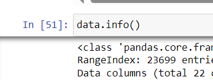

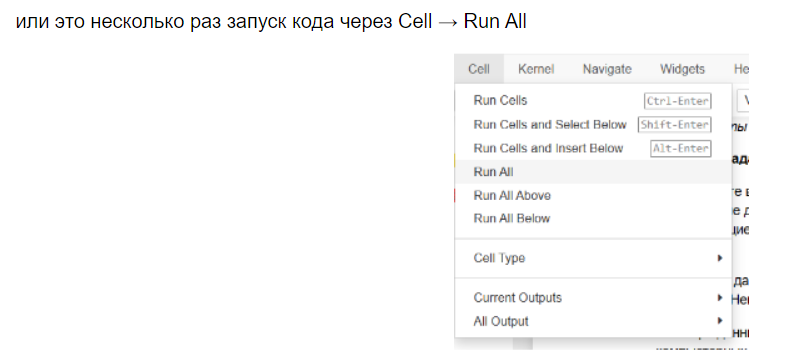

Проверить работоспособность кода — можно нажав на панели Jupiter Hub Kernel и Restart & Run All (см скриншот ниже).

[figure not shown]

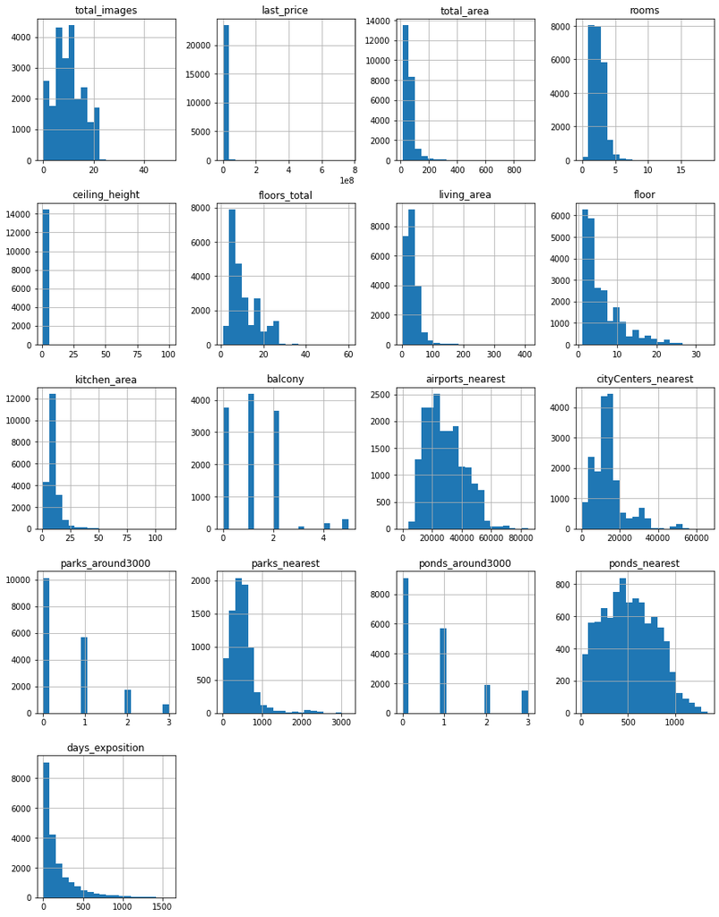

```python
data.hist(figsize=(15, 20), bins=20)
plt.show()
```

```python
data.isnull().sum ()
```

```
total_images                0
last_price                  0
total_area                  0
first_day_exposition        0
rooms                       0
ceiling_height           9195
floors_total               86
living_area              1903
floor                       0
is_apartment            20924
studio                      0
open_plan                   0
kitchen_area             2278
balcony                 11519
locality_name              49
airports_nearest         5542
cityCenters_nearest      5519
parks_around3000         5518
parks_nearest           15620
ponds_around3000         5518
ponds_nearest           14589
days_exposition          3181
dtype: int64
```

**✔️ Комментарий ревьюера**  
Выбран метод .isnull() для поиска пропущенных значений, это отлично!

isnull() и isna() делают одно и то же, но использование isna() предпочтительнее. Звучание методов: **isna(), notna() и fillna(), dropna()** помогает запомнить их быстрее 🤝

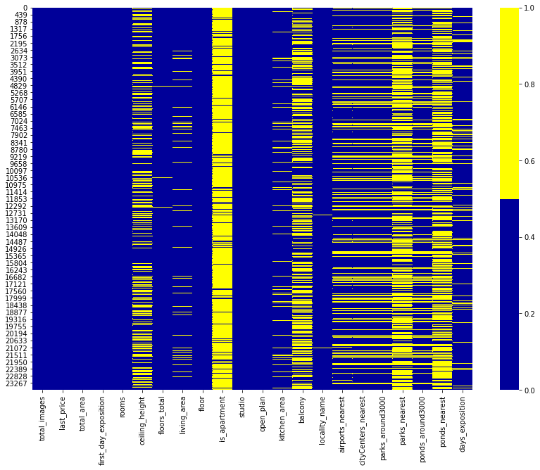

```python
colours = ['#000099', '#ffff00']
plt.figure(figsize=(14, 10))
sns.heatmap(data.isnull(), cmap=sns.color_palette(colours))
# желтым цветом отмеченны пропуски
```

```python
for col in data.columns:
    pct_missing = np.mean(data[col].isnull())
    print('{} - {}%'.format(col, round(pct_missing*100)))
```

```
total_images - 0%
last_price - 0%
total_area - 0%
first_day_exposition - 0%
rooms - 0%
ceiling_height - 39%
floors_total - 0%
living_area - 8%
floor - 0%
is_apartment - 88%
studio - 0%
open_plan - 0%
kitchen_area - 10%
balcony - 49%
locality_name - 0%
airports_nearest - 23%
cityCenters_nearest - 23%
parks_around3000 - 23%
parks_nearest - 66%
ponds_around3000 - 23%
ponds_nearest - 62%
days_exposition - 13%
```

```python
# check
# пропущенные значения бары

def pass_value_barh(dfg):
    try:
        (
            (dfg.isna().mean()*100)
            .to_frame()
            .rename(columns = {0:'space'})
            .query('space > 0')
            .sort_values(by = 'space', ascending = True)
            .plot(kind = 'barh', figsize = (19,6), rot = -5, legend = False, fontsize = 16)
            .set_title('Пример' + "\n", fontsize = 22, color = 'SteelBlue')
        );
    except:
        print('пропусков не осталось :) или произошла ошибка в первой части функции ')
```

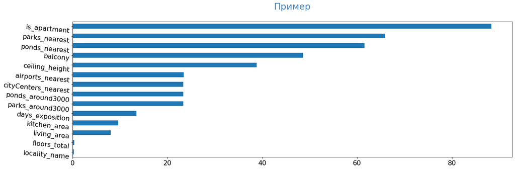

```python
pass_value_barh(data)
```

🍕 **Комментарий ревьюера**  
Наглядность представления информации одна из важных составляющих работы дата-аналитика или дата-сайентиста

**мой график оформлен не совсем корректно, сможешь отметить, что стоило бы исправить в графике?**

Единственное, что заметил ось x не подписана,больше не чего не нашел.

###### Вывод

**⚠️ Комментарий ревьюера**  
обзор данных проведен корректно, не помешает добавить вывод после первого знакомства с данными

### Выполните предобработку данных

##### пропущенные значения в ceiling_height

```python
plt.figure(figsize=(10, 6))
plt.boxplot(ceiling_height_cleaned)
plt.ylabel('Высота потолков')
plt.ylim(1, 9)
plt.show()
```

[output not shown]

```python
print(sorted(data['ceiling_height'].unique()))
```

#### check nan

```python
# check
data.info()
```

```python
#//ceiling_height_cleaned = data['ceiling_height'].dropna()
#//filtered_data = data[(data['ceiling_height'] >= 2.4) & (data['ceiling_height'] <= 6)].copy()
#//ceiling_height_median = filtered_data['ceiling_height'].median()
#//filtered_data.loc[:, 'ceiling_height'] = filtered_data['ceiling_height'].fillna(ceiling_height_median)
df['price'] = df['price'].mask(~df['price'].str.isnumeric())

df.loc[df['this_column'].isnull()]
data['ceiling_height'] = data['ceiling_height'].where((data['ceiling_height'] >= 2.4) & (data['ceiling_height'] <= 6))
```

###### в в ceiling_height были аномалии в виде слишком маленьких значений и большик. По госту потолки не могут быть ниже 2.4 и выше 6 я не нашел квартиры в питрере.

```python
# check
filtered_data.shape[0]
```

**❌ Комментарий ревьюера**

```
filtered_data = data[(data['ceiling_height'] >= 2.4) & (data['ceiling_height'] <= 6)].copy()
```

Так мы познакомились с особенностью фильтрации в библиотеке пандас, все NaN убегают вместе со значениями, которые не подходят под нашу фильтрацию, поэтому процент потери записей огромен Минус 9 000 записей только из-за пропусков стоит настроить условия фильтрации, чтобы не потерять записи с пропусками **алгоритм фильтрации столбца с пропусками: задаем основное условие фильтрации, + прибавляем условие не трогать записи с пропусками** стоит обратить внимание на весь код фильтрации, т.к. в нескольких колонках встречаются пропуски Примеры, в которых учитываются пропуски в записях  
[How to Select Rows with NaN](https://www.statology.org/pandas-select-rows-with-nan/) Чтобы сохранить записи с пропусками можно воспользоваться функцией drop

Пример с drop

**❌ Комментарий ревьюера**  
При фильтрации хвостов, стоит использоват гистограммы. Более подробная подсказка в разеделе

```
    check gap
```

###### пропущенные значения в balcony floors_total locality_name

```python
filtered_data['balcony'].fillna(0, inplace=True)
```

```python
filtered_data.dropna(subset=['floors_total', 'locality_name'], inplace=True)
```

###### в balcony я зменил пропуски на 0. floors_total , locality_name было неме=ного пропусков по этому я просто решил удалить.

🤝

###### прочитав задания я понял что не нужны для задания

is_apartment studio open_plan balcony airports_nearest ponds_around3000 ponds_nearest

```python
#filtered_data.drop('is_apartment', axis= 1 , inplace= True )
#filtered_data.drop('studio', axis= 1 , inplace= True )
#filtered_data.drop('open_plan', axis= 1 , inplace= True )
#filtered_data.drop('balcony', axis= 1 , inplace= True )
#filtered_data.drop('airports_nearest', axis= 1 , inplace= True )
#filtered_data.drop('ponds_around3000', axis= 1 , inplace= True )
#filtered_data.drop('ponds_nearest', axis= 1 , inplace= True )

filtered_data.drop(['is_apartment', 'studio', 'open_plan', 'balcony', 'airports_nearest', 'ponds_around3000', 'ponds_nearest'], axis=1, inplace=True)
```

**⚠️ Комментарий ревьюера**  
цикл for остался без работы

```
    filtered_data.drop('is_apartment', axis= 1 , inplace= True )
    filtered_data.drop('studio', axis= 1 , inplace= True )
    filtered_data.drop('open_plan', axis= 1 , inplace= True )
    filtered_data.drop('balcony', axis= 1 , inplace= True )
    filtered_data.drop('airports_nearest', axis= 1 , inplace= True )
    filtered_data.drop('ponds_around3000', axis= 1 , inplace= True )
    filtered_data.drop('ponds_nearest', axis= 1 , inplace= True )
```

можно объединить код

###### days_exposition-нету данных чтобы заполнить пропуки

cityCenters_nearest- kitchen_area-я хотел посчитать из общей площади и отнять комнаты но потом понял что инфы не хвает living_area-я хотел посчитать из общей площади и отнять комнаты но потом понял что инфы не хвает

**⚠️ Комментарий ревьюера**  
Жилую площадь заполнить можно, но там потребуются доп. затраты времени, если срок проекта горит, можно не заполнять

###### parks_around3000 - 0 нету рядом парков

parks_nearest - нашел стистику нв 2003 год что в питере что 68 парков

```python
filtered_data['parks_around3000'] = filtered_data['parks_around3000'].fillna(0)
#filtered_data['parks_nearest'] = filtered_data['parks_nearest'].fillna(4600)
# я сегодня понял, что так много данных нелья заемень, я не могу придумать как их можно воставить.по этуму оставлю так
```

**❌ Комментарий ревьюера**  
Скажи пожалуйста, по какой причине мы заполняем несколько тысяч пропусков одним значением?

```
    filtered_data['parks_nearest'] = filtered_data['parks_nearest'].fillna(4600)
```

```python
me = filtered_data['cityCenters_nearest'].median()
filtered_data['cityCenters_nearest'].fillna(me, inplace=True)

#ничего не придумал лучше чем медиану вписать
```

**❌ Комментарий ревьюера**  
Не изучено распределение пропусков по городам до заполнения значений в ['city_сenters_nearest']

```
    me = filtered_data['cityCenters_nearest'].median()
    filtered_data['cityCenters_nearest'].fillna(me, inplace=True)
```

к каким населенным пунктам относятся пропуски и самое важное — нет оценки степени влияния пропусков на дальнейший анализ (будут мешать выполнить проект или нет )

```python
colours = ['#000099', '#ffff00']
plt.figure(figsize=(14, 10))
sns.heatmap(filtered_data.isnull(), cmap=sns.color_palette(colours))
```

first_day_exposition-дата поменял datetime64 floors_total-поменял на int будет целые значение cityCenters_nearest-поменял на int будет целые значение parks_around3000-поменял на int будет целые значение parks_nearest-поменял на int будет целые значение

```python
filtered_data['first_day_exposition'] = pd.to_datetime(filtered_data['first_day_exposition'], format='%Y-%m-%dT%H:%M:%S')

#filtered_data['floors_total'] = filtered_data['floors_total'].astype(int)
#filtered_data['cityCenters_nearest'] = filtered_data['cityCenters_nearest'].astype(int)
#filtered_data['parks_around3000'] = filtered_data['parks_around3000'].astype(int)
#filtered_data['parks_nearest'] = filtered_data['parks_nearest'].astype(int)

filtered_data = filtered_data.astype({
    'floors_total': int,
    'cityCenters_nearest': int,
    'parks_around3000': int,
    'parks_nearest': int
})
```

**⚠️ Комментарий ревьюера**  
можно объединить часть кода ⬆

```python
filtered_data.dtypes
```

[output not shown]

```python
filtered_data['locality_name'].nunique()
```

[output not shown]

```python
filtered_data['locality_name'].unique()
```

**❌ Комментарий ревьюера**  
Стоит выполнить п. проекта

Шаг 2. Предобработка данных 3. Изучите уникальные значения в столбце с названиями и устраните неявные дубликаты. Например, «поселок Рябово» и «поселок городского типа Рябово», «поселок Тельмана» и «посёлок Тельмана» — это обозначения одних и тех же населённых пунктов. Вы можете заменить названия в существующем столбце или создать новый с названиями без дубликатов.

🍕 **Комментарий ревьюера**

Для того, **чтобы изменить лишь часть строки,** можно добавить к коду — .str

```
    .str.replace('посёлок','поселок')
```

https://pandas.pydata.org/pandas-docs/stable/reference/api/pandas.Series.str.replace.html

**❌ Комментарий ревьюера**  
Стоит добавить короткий обобщающий вывод по результатам выполнения раздела проекта

### Добавьте в таблицу новые столбцы

цена одного квадратного метра

```python
filtered_data['price_meter'] = filtered_data['last_price'] // filtered_data['total_area']
```

```python
filtered_data['year_exposition'] = filtered_data['first_day_exposition'].dt.year
filtered_data['month_exposition'] = filtered_data['first_day_exposition'].dt.month
filtered_data['weekday_exposition'] = filtered_data['first_day_exposition'].dt.weekday
filtered_data['day_exposition'] = filtered_data['first_day_exposition'].dt.day
```

**⚠️ Комментарий ревьюера**  
Создана новая колонка, которая почти не отличается по имени от основной:

```
    ['day_exposition']

    ['days_exposition'] - скорость продаж
```

стоит переименовать → 'day_exposition'

```python
def get_type_floor(row):
    if row['floor'] == 1:
        return 'первый'
    elif row['floor'] == row['floors_total']:
        return 'последний'
    return 'другой'

filtered_data['type_floor'] =  filtered_data.apply(get_type_floor, axis=1)
```

**⚠️ Комментарий ревьюера**  
Функция хорошая, стоит учесть крайние условия: возможные нулевые и отрицательные значения, все подобные записи попадут в категорию средних этажей

```python
#cityCenters_nearest
filtered_data['сenters_meter']=filtered_data['cityCenters_nearest'] // 1000
```

**✔️ Комментарий ревьюера**  
данные добавлены корректно, молодец

### Проведите исследовательский анализ данных

**❌ Комментарий ревьюера**  
Стоит выполнить п.4.1 проекта

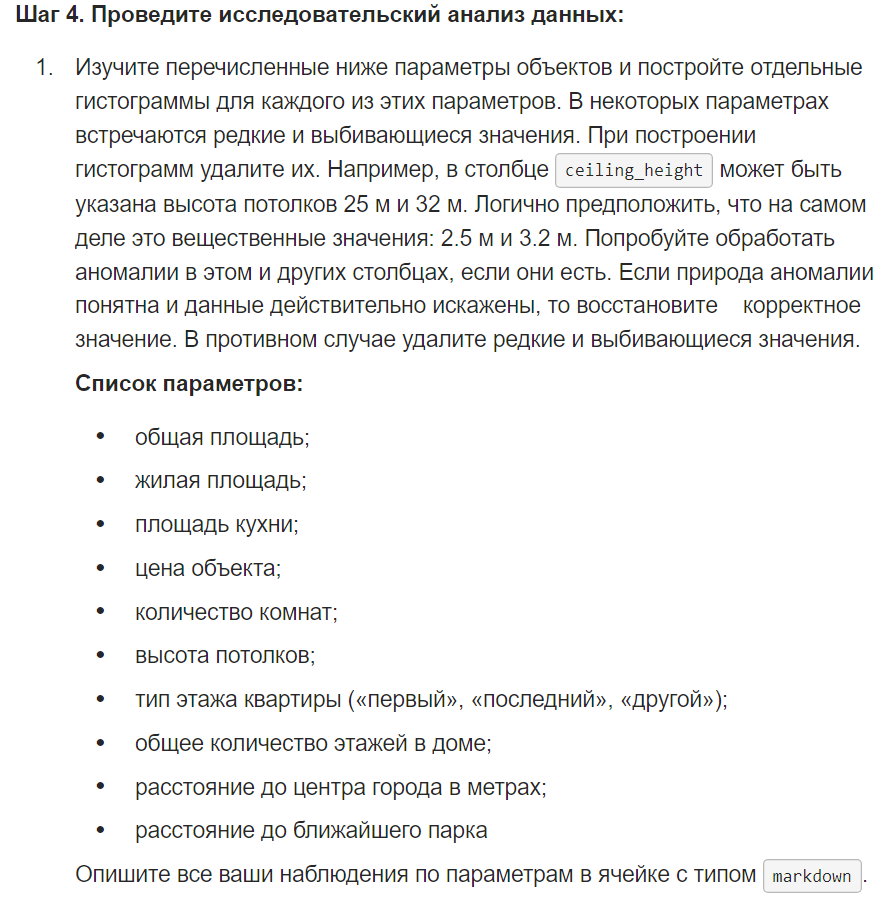

#### check gap

```python
# check
data.info()
```

```python
# check
filtered_data.info()
```

**✔️ Комментарий ревьюера**

```python
# check

# Показатели о кол-ве объявлений в датасете, минимальных и максимальных значениях
# в выбранных параметрах о продаже квартир

(
    filtered_data[['rooms', 'total_area', 'ceiling_height', 'days_exposition', 'last_price', 'living_area',  'kitchen_area',
          'floor', 'floors_total']]
    .apply (['count', 'min', 'max'])
    .style.format("{:,.2f}")
)
```

[output not shown]

**❌ Комментарий ревьюера**  
остались аномалии и редкости (в т.ч. и хвосты) в колонках:

```
    'rooms', 'total_area', 'ceiling_height', 'days_exposition', 'last_price', 'living_area',  'kitchen_area', 'floors_total'
```

стоит обратить внимание на минимальные и максимальные значения в выборке и учесть наличие пропусков при фильтрации данных

**⚠️ Комментарий ревьюера**  
Доп. задание, на твое усмотрение — сможешь добавить в таблицу расчет медианного значения?

```
    (
        data[['rooms', 'total_area', 'ceiling_height', 'days_exposition', 'last_price', 'living_area',  'kitchen_area',
              'floor', 'floors_total']]
        .apply (['count', 'min', 'max'])
        .style.format("{:,.2f}")
    )
```

**✔️ Комментарий ревьюера**  
Для выполнения пункта 4.1. (или в старой версии п.2.4) существует два подхода

Можно механически бороться с выбросами (при помощи межквартильного размаха), ... основная проблема такого подхода — не учитывается неоднородность нашей выборки: у нас здесь и малые поселки, и вторая столица страны, и исторический фонд и массовая застройка, и однушки и довольно большое кол-во многокомнатных квартир, или наоборот одна две квартиры с количеством комнат больше 7-ми ...

если бы у нас в таблице были бы только однокомнатные квартиры из определенного района массовой застройки, тогда да, мы бы боролись с выбросами традиционными способами, при нашем многообразии населенных пунктов, многокомнатности такие подходы не работают... т.е. они работают, но это усложнит наш проект — придется разбить и объединить записи нашей таблицы по нескольким параметрам (кол-во комнат, район, и т.д.), а затем только выполнять все остальные пункты на каждой отдельной выборке Остается другой подход — убираем редкие значения и следим за количеством потерь... Для выборки из 23-х тысяч значений, несколько записей со стоимостью квадратного метра выше 1-го млн. руб., довольно редкое явление

Хороший пример, высота потолков, которую мы отрезаем по нижней и верхней планке, это скорее аномальные записи, посмотрим на другой аспект — на редкости: кол-во комнат

**т.е. мы не говорим о том, что квартир с кол-ом комнат выше 7 не бывает, мы говорим, что для нашего исследования это редкие выбивающиеся из общей картины уникальные объекты, по которым необходимо проводить отдельную работу ...** подобным образом рассматриваем и остальные параметры наши помощники

1. гистограммы, с хорошим масштабом
2. метод describe() или облегченная версия, пример выше
3. метод value_counts()

плюс жизненный опыт

```python
# check

try:
    df_check = pd.read_csv('https://code.s3.yandex.net/datasets/real_estate_data.csv', sep='\t')
# если не получилось прочитать файл из локальной папки, то загружаем данные из сети
except:
    df_check = pd.read_csv('real_estate_data.csv', sep='\t')
```

```python
# check
df_check.rooms.value_counts().to_frame()
```

```python
# check
df_check.total_area.hist(bins = 150, figsize = (15,3));
```

[output not shown]

```python
# check
df_check.total_area.hist(bins = 150, figsize = (15,3), range = (180,500));
```

```python
# check
df_check.total_area.hist(bins = 15, figsize = (15,3), range = (180,500));
```

```python
# check
df_check.total_area.hist(bins = 15, figsize = (15,3), range = (0,25));
```

**❌ Комментарий ревьюера**  
Осталось выполнить пункт 4.1 (в старой версии п.2.4) из брифа проекта

В некоторых параметрах встречаются редкие и выбивающиеся значения. При построении гистограмм удалите их. Например, в столбце ceiling_height может быть указана высота потолков 25 м и 32 м. Логично предположить, что на самом деле это вещественные значения: 2.5 м и 3.2 м. Попробуйте обработать аномалии в этом и других столбцах, если они есть. Если природа аномалии понятна и данные действительно искажены, то восстановите корректное значение. В противном случае удалите редкие и выбивающиеся значения. **Критичный уровень потерь записей на этапе предобработки составляет 10%, оптимальный 5%** Если при фильтрации одной колонки, на этом проекте, теряем больше одного процента данных от изначального объема, стоит еще раз пересмотреть условия фильтрации

```python
# check

# Значения параметров объектов недвижимости на разных квантилях

(
    data[['rooms', 'total_area', 'ceiling_height', 'days_exposition', 'last_price', 'living_area',
        'kitchen_area', 'floor',   'floors_total']]
    .quantile([0.0012, 0.01, .5, .99, .9988]) # выбираем размах в 0,9976 квантилей
    .style.format("{:,.2f}")
)
```

**✔️ Комментарий ревьюера**  
Квантили что это такое (первая ссылка иногда не открывается)

https://fin-accounting.ru/cfa/l1/quantitative/cfa-quartiles-quintiles-deciles-percentiles?ysclid=l7gy2kky4i156375632 https://www.codecamp.ru/blog/percentile-vs-quartile-vs-quantile/?ysclid=lg89wjm4zz267333250  
они помогают увидеть редкости и аномалии в данных

#### check

```python
filtered_data.hist (column='days_exposition', bins='auto' , rwidth= .9 , color='purple')
ax = plt.gca()
ax.set_xlabel('Дни продажи')
ax.set_ylabel('Частота')
ax.set_title('Гистограмма времени продажи квартир')
```

[output not shown]

🍕 **Комментарий ревьюера**  
Скрыть служ. информацию поможет точка с запятой на посл. строке кода

```
Text(0.5, 1.0, 'Гистограмма времени продажи квартир')

ax.set_title('Гистограмма времени продажи квартир');
```

```python
print(filtered_data['days_exposition']. median())
print(filtered_data['days_exposition']. mean())
```

**⚠️Комментарий ревьюера**

**Интересно посмотреть на изменение средней скорости продаж по годам**

**⚠️Комментарий ревьюера**  
Не исследованы моды (пиковые значения) в 'days_exposition' и как они влияют на скорость продажи, подсказка на что смотреть

[Условия размещения объявлений](https://yandex.ru/support/realty/owner/home/add-ads-housing.html)

# example 1

#### example 3

##### example 4

🍕 **Комментарий ревьюера**  
Стоит выделять разделы проекта заголовками разного уровня, за уровень отвечает количество знаков #

```
    # example 1

    #### example 3

    ##### example 4
```

Пожалуйста, воспользуйся методичкой по оформлению проектов. Ее можно найти в блоке курса: Полезные инструкции для учёбы - Оформление проекта - Рекомендации по выполнению проектов

```python
filtered_data.plot(x='total_area', y='last_price', kind='scatter', alpha=0.5)

plt.xlabel('Площадь')
plt.ylabel('Цена')
plt.title('Зависимость цены от площади квартир')
```

[output not shown]

🍕 **Комментарий ревьюера**  
Можно попробовать настроить вид точечных графиков

[Как сделать диаграмму рассеяния из фрейма данных Pandas](https://www.codecamp.ru/blog/pandas-scatter-plot/?ysclid=lh0tbpkoa9628147030)

Примеры расчета коэф. корреляции и не только Исследуем отношение между переменными

[Примеры графиков](https://proglib.io/p/kollekciya-prodvinutoy-vizualizacii-v-matplotlib-i-seaborn-s-primerami-2021-02-11?ysclid=ltnocrlmos378496858)

```python
filtered_data.plot(x='living_area', y='last_price', kind='scatter', alpha=0.5)

plt.xlabel('Площадь жилая')
plt.ylabel('Цена')
plt.title('Зависимость цены от площади квартир')
```

[output not shown]

```python
filtered_data.plot(x='kitchen_area', y='last_price', kind='scatter', alpha=0.5)

plt.xlabel('Площадь кухни')
plt.ylabel('Цена')
plt.title('Зависимость цены от площади кухни')
```

[output not shown]

**❌ Комментарий ревьюера**  
Стоит добавить расчет коэффициента корреляции для поиска линейных зависимостей

```python
plt.bar(filtered_data['rooms'], filtered_data['last_price'], color='blue', alpha=0.7)
plt.xlabel('Комнат')
plt.ylabel('Цена')
plt.title('Зависимость цены от количества комнт')
plt.xticks(range(min(filtered_data['rooms']), max(filtered_data['rooms'])+1))
```

**❌ Комментарий ревьюера**  
Скажи пожалуйста, что нарисовано на этом графике, что означает каждый цвет?

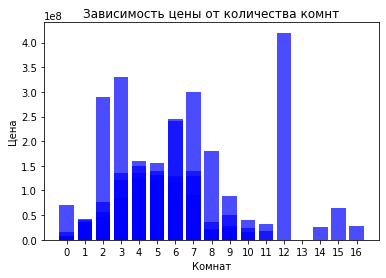

Этот вопрос касается всех подобных графиков ⬇⬇

```python
plt.bar(filtered_data['type_floor'], filtered_data['last_price'], color='blue', alpha=0.7)

plt.xlabel('Тип этажа')
plt.ylabel('Цена')
plt.title('Зависимость цены от типа этажа')
```

[output not shown]

```python
plt.bar(filtered_data['year_exposition'], filtered_data['last_price'], color='blue', alpha=0.7)

plt.xlabel('год')
plt.ylabel('Цена')
plt.title('Зависимость года')
```

[output not shown]

```python
plt.bar(filtered_data['month_exposition'], filtered_data['last_price'], color='blue', alpha=0.7)

plt.xlabel('месяц')
plt.ylabel('Цена')
plt.title('Зависимость цены от месяца')
```

[output not shown]

```python
plt.bar(filtered_data['weekday_exposition'], filtered_data['last_price'], color='blue', alpha=0.7)

plt.xlabel('дня')
plt.ylabel('Цена')
plt.title('Зависимость цены от дня')
```

[output not shown]

**❌ Комментарий ревьюера**  
Стоит перерисовать 5 последних графиков или добавить новые

```
+    количества комнат;
+	этажа, на котором расположена квартира (первый, последний, другой);
+	даты размещения (день недели, месяц, год).
```

Постройте графики, которые покажут зависимость цены от указанных выше параметров. Для подготовки данных перед визуализацией вы можете использовать сводные таблицы.

Советы по графикам: оптимальнее рассматривать

- динамику — на линейных графиках (это про сравнение цен за год, месяц, день недели), — стоит сгруппировать значения и рассчитать среднее или медианное значение
- сравнение цен — на барах (для сравнение средней стоимости квартиры по трем категориям или по комнатам), — стоит сгруппировать значения и рассчитать среднее или медианное значение

**🍕 Комментарий ревьюера**  
Еще одна особенность подобных графиков

```
    plt.bar(filtered_data['year_exposition'], filtered_data['last_price'], color='blue', alpha=0.7)
```

они очень долго формируются, т.к. нет предварительной группировки

```python
ads_per_locality = filtered_data['locality_name'].value_counts().head(10)
print(ads_per_locality)
```

```python
top_localities = ads_per_locality.index


average_price = filtered_data.groupby('locality_name')['last_price'].mean()


highest_price_locality =filtered_data.last_price.idxmax()
lowest_price_locality = filtered_data.last_price.idxmin()


print("10 населённых пунктов с наибольшим числом объявлений:")
print(top_localities)
print("высокой средней ценой за квадратный метр:", highest_price_locality)
print("низкой средней ценой за квадратный метр:", lowest_price_locality)
```

**❌ Комментарий ревьюера**  
Осталось пересчитать: сначала составляем список из десяти населенных пунктов в которых наибольшее кол-во объявлений, затем рассчитываем среднюю стоимость кв. м. по населенным пунктам из полученного списка, затем строим график (бары), чтобы наглядно показать разницу в средней цене кв. метра ...

Шаг 4. Проведите исследовательский анализ данных:

4. Посчитайте среднюю цену одного квадратного метра в 10 населённых пунктах с наибольшим числом объявлений. Выделите населённые пункты с самой высокой и низкой стоимостью квадратного метра. Эти данные можно найти по имени в столбце locality_name.

🍕 **Комментарий ревьюера**

[Постер поможет выбирать вид графиков](https://www.notion.so/6c5ae8ceb8b5411e907c93c9b5e6a44e)

**❌ Комментарий ревьюера**  
Стоит поправить вывод, мы ищем максимальное и минимальное значение среди ТОП-10 по кол-ву объявлений

```python
spb_flats = filtered_data[filtered_data['locality_name'] == 'Санкт-Петербург']
distance_to_center = spb_flats['cityCenters_nearest'] / 1000
average_price_by_distance = spb_flats.groupby(distance_to_center)['last_price'].mean()
plt.plot(average_price_by_distance.index, average_price_by_distance.values)
plt.xlabel('Расстояние до центра, км')
plt.ylabel('Средняя цена')
plt.title('Зависимость средней цены от расстояния до центра Санкт-Петербурга')
```

[output not shown]

**❌ Комментарий ревьюера**

Для выполнения 5-го пункта стоит сгруппировать и найти среднюю стоимость только питерских квартир на каждом километре, на этих данных построить линейный график, где по оси х будут округленные км., а по оси у - средняя стоимость всех квартир на этом км.

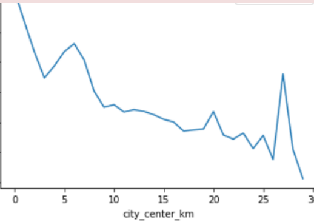

Шаг 4. 5. Ранее вы посчитали расстояние до центра в километрах. Теперь выделите квартиры в Санкт-Петербурге с помощью столбца locality_name и вычислите среднюю цену каждого километра. Опишите, как стоимость объектов зависит от расстояния до центра города.

**❌ Комментарий ревьюера**  
Стоит изучить записи, которые привели к выбросу на 27-м км.

**❌ Комментарий ревьюера**  
Стоит посмотреть на количество квартир разных категорий (первый, последний, другой), которые продаются на 3-м км. и 5-ом ... и какую долю они занимают на каждом километре, чтобы объяснить пик и провал в центре

```
    выполняется при помощи группировки или свода данных
```

### Напишите общий вывод

**❌ Комментарий ревьюера**

Оформление вывода: стоит кратко напомнить цель исследования, как мы его провели, какие параметры рассматривали, какие редкие и выбивающиеся значения убрали, какие особенности и инсайты в данных нашли (упоминаем только основные 3-5, с приведением найденных чисел), выделяем сильные корреляционные связи на парных признаках, если есть

- можно представить средние значения параметров, которые были исследованы

В окончательном выводе могут быть и такие предположения, что такой-то и такой-то сегмент квартир стоит изучить в таком разрезе, своде и т.д., т.о. очертив себе план будущих исследований :)

**✔️ Комментарий ревьюера**  
Выполнил исследовательскую работу, молодец

Критические ❌ комментарии

- проверить корректность заполнения пропусков
- отформатировать неявные дубликаты
- добавить гистограммы в п.4.1
- настроить фильтрацию редких значений
- добавить расчет коэффициента корреляции для поиска линейной зависимости
- поправить графики и добавить вывод в п. 4.3
- поправить выполнение и добавить график в ТОП-10
- поправить выполнение и исследовать аномалии в п.4.5
- поправить итоговый вывод

С ними важно поработать и исправить Стоит обратить внимание и на такие комментарии ⚠️ Если будут вопросы про мои комментарии - задавай, если какой-то формат взаимодействия не устраивает или есть какие-то другие пожелания - пиши :)

**Жду твой проект и твои комментарии 🤝**

нумерация пунктов из брифа проекта, у тебя они могут быть другие

если не заметил твоих вопросов, просьба выделить цветом

**Для успешного исправления комментариев стоит прочитать справочные материалы ⬇⬇⬇**

🍕 **Комментарий ревьюера**

[Обработка пропусков в данных](https://loginom.ru/blog/missing) Подробное руководство по группировке и агрегированию с помощью pandas

[Сводная таблица в pandas](https://dfedorov.spb.ru/pandas/%D0%A1%D0%B2%D0%BE%D0%B4%D0%BD%D0%B0%D1%8F%20%D1%82%D0%B0%D0%B1%D0%BB%D0%B8%D1%86%D0%B0%20%D0%B2%20pandas.html?ysclid=lje9wz2vfc28794921) [Понимание функции transform в Pandas](https://dfedorov.spb.ru/pandas/%D0%9F%D0%BE%D0%BD%D0%B8%D0%BC%D0%B0%D0%BD%D0%B8%D0%B5%20%D1%84%D1%83%D0%BD%D0%BA%D1%86%D0%B8%D0%B8%20transform%20%D0%B2%20Pandas.html)

Как выбрать определенные столбцы из DataFrame

[How to visualise data using histograms in Pandas](https://practicaldatascience.co.uk/data-science/how-to-visualise-data-using-histograms-in-pandas)

[8 способов фильтрации фреймов данных Pandas](https://questu.ru/articles/85248/)

**Чек-лист готовности проекта**

Поставьте 'x' в выполненных пунктах. Далее нажмите Shift+Enter.

- Файл с данными открыт.
- Файл с данными изучен: выведены первые строки, использован метод `info()`, построены гистограммы.
- Найдены пропущенные значения.
- Пропущенные значения заполнены там, где это возможно.
- Объяснено, какие пропущенные значения обнаружены.
- В каждом столбце установлен корректный тип данных.
- Объяснено, в каких столбцах изменён тип данных и почему.
- Устранены неявные дубликаты в названиях населённых пунктов.
- Обработаны редкие и выбивающиеся значения (аномалии).
- В таблицу добавлены новые параметры: – цена одного квадратного метра; – день публикации объявления (0 - понедельник, 1 - вторник и т. д.); – месяц публикации объявления; – год публикации объявления; – тип этажа квартиры (значения — «первый», «последний», «другой»); – расстояние до центра города в километрах.
- Изучены и описаны параметры: - общая площадь; - жилая площадь; - площадь кухни; - цена объекта; - количество комнат; - высота потолков; - тип этажа квартиры («первый», «последний», «другой»); - общее количество этажей в доме; - расстояние до центра города в метрах; - расстояние до ближайшего парка.
- Выполнено задание «Изучите, как быстро продавались квартиры (столбец `days_exposition`)»:
  - построена гистограмма;
  - рассчитаны среднее и медиана;
  - описано, сколько обычно занимает продажа и указано, какие продажи можно считать быстрыми, а какие — необычно долгими.
- Выполнено задание «Определите факторы, которые больше всего влияют на общую (полную) стоимость объекта». Построены графики, которые показывают зависимость цены от параметров: - общая площадь; - жилая площадь; - площадь кухни; - количество комнат; - тип этажа, на котором расположена квартира (первый, последний, другой); - дата размещения (день недели, месяц, год).
- Выполнено задание «Посчитайте среднюю цену одного квадратного метра в 10 населённых пунктах с наибольшим числом объявлений»:
  - выделены населённые пункты с самой высокой и низкой стоимостью квадратного метра.
- Выполнено задание «Выделите квартиры в Санкт-Петербурге с помощью столбца `locality_name` и вычислите их среднюю стоимость на разном удалении от центра»:
  - учтён каждый километр расстояния, известны средние цены квартир в одном километре от центра, в двух и так далее;
  - описано, как стоимость объекта зависит от расстояния до центра города;
  - построен график изменения средней цены для каждого километра от центра Петербурга.
- На каждом этапе сделаны промежуточные выводы.
- В конце проекта сделан общий вывод.